# Modeling

Author

Kiera Murray

Published

November 16, 2026

# Setup

```r
# Load packages
pacman::p_load(tidyverse, lme4, lmerTest, lmtest,
               pacman, grateful, here, usethis)
```

```r
# Set blank slate
usethis::use_blank_slate(scope = "user")

# Citations
grateful::cite_packages(pkgs='Session', output='paragraph', out.dir='.')
```

We used R v. 4.5.2 [@base] and the following R packages: here v. 1.0.2 [@here], lme4 v. 2.0.1 [@lme4], lmerTest v. 3.2.1 [@lmerTest], lmtest v. 0.9.40 [@lmtest], Matrix v. 1.7.5 [@Matrix], pacman v. 0.5.1 [@pacman], tidyverse v. 2.0.0 [@tidyverse], usethis v. 3.2.2 [@usethis], zoo v. 1.8.15 [@zoo].

```r
print(paste("operating system: ", sessionInfo()$running))
```

```
[1] "operating system:  macOS Tahoe 26.5.2"
```

```r
# Check working directory
here()
```

```
[1] "/Users/kieramurray/Library/CloudStorage/OneDrive-Personal/Grad School/Biostats in Action/BIOSTATS-690E-Capstone"
```

# Replicating the original ANCOVA analysis

## Using the original dataset

```r
# Load data
load(here("data", "processed", "acupunc_full.RData"))
summary(acupunc_full)
```

```
       id           age            sex              migraine     chronicity
 100    :  1   Min.   :18.00   female:337   migraine    :377   Min.   : 1.00
 101    :  1   1st Qu.:39.00   male  : 64   tension-type: 24   1st Qu.:10.00
 104    :  1   Median :48.00                                   Median :20.00
 105    :  1   Mean   :45.54                                   Mean   :21.46
 108    :  1   3rd Qu.:53.00                                   3rd Qu.:31.00
 112    :  1   Max.   :65.00                                   Max.   :54.00
 (Other):395
 acupuncturist         group          pk1             pk2
 3      :91    acupuncture:205   Min.   : 6.75   Min.   : 0.00
 8      :61    control    :196   1st Qu.:15.00   1st Qu.:10.75
 6      :56                      Median :21.00   Median :16.88
 7      :38                      Mean   :26.51   Mean   :21.60
 9      :36                      3rd Qu.:34.25   3rd Qu.:27.00
 11     :34                      Max.   :94.75   Max.   :98.50
 (Other):85                                      NA's   :75
      pk5              f1              f2              f5               gp
 Min.   : 0.00   Min.   : 3.00   Min.   : 0.00   Min.   : 0.000   18     : 43
 1st Qu.: 8.50   1st Qu.:10.00   1st Qu.: 4.00   1st Qu.: 0.000   12     : 37
 Median :15.00   Median :15.00   Median :10.00   Median : 8.000   41     : 32
 Mean   :19.08   Mean   :16.18   Mean   :10.94   Mean   : 9.319   10     : 24
 3rd Qu.:25.25   3rd Qu.:21.00   3rd Qu.:17.00   3rd Qu.:14.000   16     : 22
 Max.   :87.25   Max.   :28.00   Max.   :28.00   Max.   :28.000   40     : 22
 NA's   :100                                                      (Other):221
```

Outcome variable: `pk5` (headache score at 1-year follow-up)

Main predictor variable: treatment `group`

Covariates: `age`, `sex`, `migraine` (migraine vs. tension-type headache), `chronicity` (years with headache disorder), `pk1` (baseline headache score)

```r
# Fit the model:
ancova_model <- lm(pk5 ~ group + age + sex + migraine + chronicity + pk1,
                   data = acupunc_full)
summary(ancova_model)
```

```
Call:
lm(formula = pk5 ~ group + age + sex + migraine + chronicity +
    pk1, data = acupunc_full)

Residuals:
    Min      1Q  Median      3Q     Max
-34.103  -6.233  -0.904   6.118  44.304

Coefficients:
                     Estimate Std. Error t value Pr(>|t|)
(Intercept)          -8.74905    3.13021  -2.795 0.005531 **
groupcontrol          4.63998    1.24044   3.741 0.000221 ***
age                   0.13848    0.06812   2.033 0.042951 *
sexmale               1.57568    1.69622   0.929 0.353685
migrainetension-type  2.97277    2.72516   1.091 0.276228
chronicity            0.03441    0.05127   0.671 0.502713
pk1                   0.70766    0.04040  17.518  < 2e-16 ***
---
Signif. codes:  0 '***' 0.001 '**' 0.01 '*' 0.05 '.' 0.1 ' ' 1

Residual standard error: 10.69 on 294 degrees of freedom
  (100 observations deleted due to missingness)
Multiple R-squared:  0.5401,    Adjusted R-squared:  0.5308
F-statistic: 57.55 on 6 and 294 DF,  p-value: < 2.2e-16
```

This matches the paper’s finding: “Scores fell by 34% in the acupuncture group compared with 16% in controls (P = 0.0002).”

Let’s check if the reduction percentages match too:

```r
# Calculate average scores for the acupuncture group
acupunc_full_acu <- acupunc_full %>% filter(group == "acupuncture") %>%
  filter(!is.na(pk5)) # keep only people with non-missing 1-year followup
acu_baseline <- mean(acupunc_full_acu$pk1)
acu_final <- mean(acupunc_full_acu$pk5)

# Calculate average scores for the control group
acupunc_full_ctrl <- acupunc_full %>% filter(group == "control") %>%
  filter(!is.na(pk5)) # keep only people with non-missing 1-year followup
ctrl_baseline <- mean(acupunc_full_ctrl$pk1)
ctrl_final <- mean(acupunc_full_ctrl$pk5)

# Calculate and print reduction percentages
print(paste("Reduction in acupuncture group:",
      round(100*(1 - acu_final/acu_baseline), 1), "percent"))
```

```
[1] "Reduction in acupuncture group: 33.9 percent"
```

```r
print(paste("Reduction in control group:",
      round(100*(1 - ctrl_final/ctrl_baseline), 1), "percent"))
```

```
[1] "Reduction in control group: 16.4 percent"
```

These values also match the paper’s reported results.

## Using only migraine patients (new analysis)

If we run the same analysis on our reduced dataset (migraine patients only), how do the results change?

```r
# Load data
load(here("data", "processed", "acupunc.RData"))
summary(acupunc)
```

```
       id           age            sex              migraine     chronicity
 100    :  1   Min.   :18.00   female:318   migraine    :377   Min.   : 1.00
 101    :  1   1st Qu.:38.00   male  : 59   tension-type:  0   1st Qu.:10.00
 104    :  1   Median :48.00                                   Median :20.00
 105    :  1   Mean   :45.42                                   Mean   :21.86
 108    :  1   3rd Qu.:53.00                                   3rd Qu.:31.00
 112    :  1   Max.   :65.00                                   Max.   :54.00
 (Other):371
 acupuncturist         group          pk1             pk2
 3      :83    acupuncture:194   Min.   : 6.75   Min.   : 0.00
 8      :58    control    :183   1st Qu.:15.00   1st Qu.:10.75
 6      :54                      Median :21.25   Median :16.75
 7      :37                      Mean   :26.61   Mean   :21.42
 9      :34                      3rd Qu.:34.50   3rd Qu.:27.06
 11     :32                      Max.   :94.75   Max.   :98.50
 (Other):79                                      NA's   :69
      pk5              f1              f2              f5               gp
 Min.   : 0.00   Min.   : 3.00   Min.   : 0.00   Min.   : 0.000   18     : 41
 1st Qu.: 8.25   1st Qu.:10.00   1st Qu.: 4.00   1st Qu.: 0.000   12     : 31
 Median :15.00   Median :15.00   Median :10.00   Median : 8.000   41     : 30
 Mean   :18.96   Mean   :16.14   Mean   :10.96   Mean   : 9.265   10     : 23
 3rd Qu.:25.06   3rd Qu.:21.00   3rd Qu.:17.00   3rd Qu.:14.000   16     : 22
 Max.   :87.25   Max.   :28.00   Max.   :28.00   Max.   :28.000   40     : 20
 NA's   :93                                                       (Other):210
```

Outcome variable: `pk5` (headache score at 1-year follow-up)

Main predictor variable: treatment `group`

Covariates: `age`, `sex`, `chronicity` (years with headache disorder), `pk1` (baseline headache score)

Note that `migraine` has been removed as a covariate since it is now redundant.

```r
# Fit the model:
ancova_model_migraine <- lm(pk5 ~ group + age + sex + chronicity + pk1,
                            data = acupunc)
summary(ancova_model_migraine)
```

```
Call:
lm(formula = pk5 ~ group + age + sex + chronicity + pk1, data = acupunc)

Residuals:
    Min      1Q  Median      3Q     Max
-33.397  -6.241  -0.972   6.156  44.623

Coefficients:
             Estimate Std. Error t value Pr(>|t|)
(Intercept)  -8.65573    3.24728  -2.666 0.008136 **
groupcontrol  4.96407    1.29527   3.832 0.000157 ***
age           0.14432    0.07075   2.040 0.042306 *
sexmale       1.44686    1.79525   0.806 0.420967
chronicity    0.02817    0.05332   0.528 0.597718
pk1           0.69375    0.04215  16.459  < 2e-16 ***
---
Signif. codes:  0 '***' 0.001 '**' 0.01 '*' 0.05 '.' 0.1 ' ' 1

Residual standard error: 10.83 on 278 degrees of freedom
  (93 observations deleted due to missingness)
Multiple R-squared:  0.5263,    Adjusted R-squared:  0.5178
F-statistic: 61.77 on 5 and 278 DF,  p-value: < 2.2e-16
```

The new p-value on treatment effect is 0.000157, which is basically the same as the original 0.000221.

Let’s check the new reduction percentages:

```r
# Calculate average scores for the acupuncture group
acupunc_acu <- acupunc %>% filter(group == "acupuncture") %>%
  filter(!is.na(pk5)) # keep only people with non-missing 1-year followup
acu_baseline_migraine <- mean(acupunc_acu$pk1)
acu_final_migraine <- mean(acupunc_acu$pk5)

# Calculate average scores for the control group
acupunc_ctrl <- acupunc %>% filter(group == "control") %>%
  filter(!is.na(pk5)) # keep only people with non-missing 1-year followup
ctrl_baseline_migraine <- mean(acupunc_ctrl$pk1)
ctrl_final_migraine <- mean(acupunc_ctrl$pk5)

# Calculate and print reduction percentages
print(paste("Reduction in acupuncture group:",
      round(100*(1 - acu_final_migraine/acu_baseline_migraine), 1),
      "percent"))
```

```
[1] "Reduction in acupuncture group: 35.2 percent"
```

```r
print(paste("Reduction in control group:",
      round(100*(1 - ctrl_final_migraine/ctrl_baseline_migraine), 1),
      "percent"))
```

```
[1] "Reduction in control group: 16.7 percent"
```

These are similar to the original percentages of 33.9% and 16.4% respectively.

In conclusion, removing tension-type patients doesn’t seem to change the model results. This may be because tension-type patients made up only 6% of the original sample.

# Mixed model with GP and patient effects

## Step 1: Simple model

We now begin our main analysis. Before adding random effects with clustering, we’ll start by finding the optimal simple model for the other variables.

Outcome variable: `score`

Main predictor variables: `group`, `time`

Covariates: `age`, `sex`, `chronicity`

### Data setup

```r
# Reshape data to have numeric columns "time" and "score" instead of pk1 etc.
acupunc_long <- acupunc %>%
  pivot_longer(cols = c(pk1, pk2, pk5),
               names_to = "pk", values_to = "score") %>%
  mutate(time = case_when(
    pk == "pk1" ~ 0,
    pk == "pk2" ~ 3,
    pk == "pk5" ~ 12,
    .default = NA # value when no above condition is matched
  ))

# Create a categorical time variable
acupunc_long$time_cat <- factor(acupunc_long$pk,
                                levels = c("pk1", "pk2", "pk5"),
                                labels = c("pk1", "pk2", "pk5"))

# Drop redundant variable `pk`
acupunc_long <- acupunc_long %>% select(-pk)

# View the reshaped data
summary(acupunc_long)
```

```
       id            age            sex              migraine
 100    :   3   Min.   :18.00   female:954   migraine    :1131
 101    :   3   1st Qu.:38.00   male  :177   tension-type:   0
 104    :   3   Median :48.00
 105    :   3   Mean   :45.42
 108    :   3   3rd Qu.:53.00
 112    :   3   Max.   :65.00
 (Other):1113
   chronicity    acupuncturist         group           f1
 Min.   : 1.00   3      :249   acupuncture:582   Min.   : 3.00
 1st Qu.:10.00   8      :174   control    :549   1st Qu.:10.00
 Median :20.00   6      :162                     Median :15.00
 Mean   :21.86   7      :111                     Mean   :16.14
 3rd Qu.:31.00   9      :102                     3rd Qu.:21.00
 Max.   :54.00   11     : 96                     Max.   :28.00
                 (Other):237
       f2              f5               gp          score            time
 Min.   : 0.00   Min.   : 0.000   18     :123   Min.   : 0.00   Min.   : 0
 1st Qu.: 4.00   1st Qu.: 0.000   12     : 93   1st Qu.:11.50   1st Qu.: 0
 Median :10.00   Median : 8.000   41     : 90   Median :18.00   Median : 3
 Mean   :10.96   Mean   : 9.265   10     : 69   Mean   :22.72   Mean   : 5
 3rd Qu.:17.00   3rd Qu.:14.000   16     : 66   3rd Qu.:29.00   3rd Qu.:12
 Max.   :28.00   Max.   :28.000   40     : 60   Max.   :98.50   Max.   :12
                                  (Other):630   NA's   :162
 time_cat
 pk1:377
 pk2:377
 pk5:377
```

### Choosing the best simple model

Should time be numeric or categorical? Address this question with a likelihood ratio test.

```r
# Simple model with numerical time
simple_num <- lm(score ~ group + time + age + sex + chronicity,
                 data = acupunc_long)

# Simple model with categorical time (pk)
simple_cat <- lm(score ~ group + time_cat + age + sex + chronicity,
                 data = acupunc_long)

# Likelihood ratio test
lrtest(simple_num, simple_cat)
```

```
Likelihood ratio test

Model 1: score ~ group + time + age + sex + chronicity
Model 2: score ~ group + time_cat + age + sex + chronicity
  #Df  LogLik Df  Chisq Pr(>Chisq)
1   7 -4055.7
2   8 -4051.5  1 8.4259   0.003699 **
---
Signif. codes:  0 '***' 0.001 '**' 0.01 '*' 0.05 '.' 0.1 ' ' 1
```

With a p-value of 0.003, it looks like the categorical time model is significantly better.

Should there be an interaction between time and group? Address this question with a likelihood ratio test. Build on the already established categorical time model.

```r
# Simple model with no interactions
simple_noint <- lm(score ~ group + time_cat + age + sex + chronicity,
                   data = acupunc_long)

# Simple model with time*group interaction
simple_int <- lm(score ~ (group * time_cat) + age + sex + chronicity,
                 data = acupunc_long)

# Likelihood ratio test
lrtest(simple_noint, simple_int)
```

```
Likelihood ratio test

Model 1: score ~ group + time_cat + age + sex + chronicity
Model 2: score ~ (group * time_cat) + age + sex + chronicity
  #Df  LogLik Df  Chisq Pr(>Chisq)
1   8 -4051.5
2  10 -4049.1  2 4.6698    0.09682 .
---
Signif. codes:  0 '***' 0.001 '**' 0.01 '*' 0.05 '.' 0.1 ' ' 1
```

With a p-value of 0.09, it looks like the interaction model might potentially be better than the no-interaction model. I’ll keep the interaction for now, and see if it becomes more or less significant when I add random effects.

Therefore, our best simple model is:

```r
summary(simple_int)
```

```
Call:
lm(formula = score ~ (group * time_cat) + age + sex + chronicity,
    data = acupunc_long)

Residuals:
    Min      1Q  Median      3Q     Max
-23.212 -10.733  -4.724   6.141  78.036

Coefficients:
                          Estimate Std. Error t value Pr(>|t|)
(Intercept)              23.736173   2.471138   9.605  < 2e-16 ***
groupcontrol              1.938658   1.636273   1.185  0.23639
time_catpk2              -7.208926   1.683935  -4.281 2.05e-05 ***
time_catpk5              -9.793528   1.719505  -5.696 1.63e-08 ***
age                      -0.009614   0.054677  -0.176  0.86046
sexmale                  -0.204598   1.426564  -0.143  0.88599
chronicity                0.109847   0.042366   2.593  0.00966 **
groupcontrol:time_catpk2  4.331886   2.441429   1.774  0.07633 .
groupcontrol:time_catpk5  4.684140   2.498245   1.875  0.06110 .
---
Signif. codes:  0 '***' 0.001 '**' 0.01 '*' 0.05 '.' 0.1 ' ' 1

Residual standard error: 15.87 on 960 degrees of freedom
  (162 observations deleted due to missingness)
Multiple R-squared:  0.07248,   Adjusted R-squared:  0.06475
F-statistic: 9.377 on 8 and 960 DF,  p-value: 1.591e-12
```

## Step 2: Patient effect

Next, we’ll add a random effect for the individual patient. This allows for clustering within person, i.e. all observations from the same person will be correlated.

Outcome variable: `score`

Main predictor variables: `group`, `time_cat` (categorical time)

Clustering: `id` (patient)

Covariates: `age`, `sex`, `chronicity`

Do we need a random slope and intercept for patient, or is just a random intercept enough? Investigate with a likelihood ratio test.

### Random intercept for Patient ID

```r
# Fit the slopes-only model
lmm_id_intercept <- lmer(score ~ (group * time_cat) + age + sex + chronicity +
                           (1 | id), data = acupunc_long)
summary(lmm_id_intercept)
```

```
Linear mixed model fit by REML. t-tests use Satterthwaite's method [
lmerModLmerTest]
Formula: score ~ (group * time_cat) + age + sex + chronicity + (1 | id)
   Data: acupunc_long

REML criterion at convergence: 7614.6

Scaled residuals:
    Min      1Q  Median      3Q     Max
-4.0756 -0.4540 -0.1035  0.4061  4.8203

Random effects:
 Groups   Name        Variance Std.Dev.
 id       (Intercept) 188.45   13.728
 Residual              70.16    8.376
Number of obs: 969, groups:  id, 377

Fixed effects:
                           Estimate Std. Error         df t value Pr(>|t|)
(Intercept)               23.126448   3.402336 387.441282   6.797 4.04e-11 ***
groupcontrol               1.948192   1.659200 502.054228   1.174  0.24088
time_catpk2               -6.973790   0.914534 605.399360  -7.626 9.45e-14 ***
time_catpk5               -8.718858   0.940402 607.885890  -9.271  < 2e-16 ***
age                        0.004816   0.080307 372.374607   0.060  0.95221
sexmale                    0.007867   2.110270 369.385265   0.004  0.99703
chronicity                 0.106025   0.064137 360.747370   1.653  0.09918 .
groupcontrol:time_catpk2   4.195574   1.334026 609.701451   3.145  0.00174 **
groupcontrol:time_catpk5   4.412125   1.374997 612.113340   3.209  0.00140 **
---
Signif. codes:  0 '***' 0.001 '**' 0.01 '*' 0.05 '.' 0.1 ' ' 1

Correlation of Fixed Effects:
            (Intr) grpcnt tm_ct2 tm_ct5 age    sexmal chrnct grp:_2
groupcontrl -0.270
time_catpk2 -0.101  0.238
time_catpk5 -0.100  0.231  0.472
age         -0.868  0.045 -0.014 -0.014
sexmale     -0.049 -0.020  0.002 -0.003 -0.042
chronicity   0.142 -0.030 -0.001  0.005 -0.511  0.004
grpcntrl:_2  0.077 -0.337 -0.685 -0.324 -0.001  0.008  0.006
grpcntrl:_5  0.077 -0.327 -0.323 -0.684  0.000  0.009 -0.001  0.467
```

### Random slope and intercept for Patient ID

It turns out that there aren’t enough degrees of freedom to fit random slopes (using categorical time) for every patient!

```r
# Try to fit the slopes-and-intercepts model
lmm_id_slope <- lmer(score ~ (group * time_cat) + age + sex + chronicity +
                       (time_cat | id), data = acupunc_long)
```

`Error: number of observations (=969) <= number of random effects (=1131) for term (time_cat | id); the random-effects parameters and the residual variance (or scale parameter) are probably unidentifiable`

Instead, we can fit a slopes-and-intercepts model using numeric time, and compare it to its intercepts-only counterpart.

```r
# Fit the slopes-and-intercepts model with numeric time
lmm_id_slope <- lmer(score ~ (group * time) + age + sex + chronicity +
                       (time | id), data = acupunc_long)
```

```
boundary (singular) fit: see help('isSingular')
```

```r
summary(lmm_id_slope)
```

```
Linear mixed model fit by REML. t-tests use Satterthwaite's method [
lmerModLmerTest]
Formula: score ~ (group * time) + age + sex + chronicity + (time | id)
   Data: acupunc_long

REML criterion at convergence: 7662.7

Scaled residuals:
    Min      1Q  Median      3Q     Max
-4.2617 -0.4624 -0.0791  0.3798  4.8066

Random effects:
 Groups   Name        Variance  Std.Dev. Corr
 id       (Intercept) 1.936e+02 13.91423
          time        3.793e-03  0.06159 -1.00
 Residual             7.419e+01  8.61315
Number of obs: 969, groups:  id, 377

Fixed effects:
                    Estimate Std. Error         df t value Pr(>|t|)
(Intercept)        21.213146   3.396326 383.391663   6.246 1.12e-09 ***
groupcontrol        3.206285   1.620180 371.691933   1.979  0.04856 *
time               -0.625480   0.078147 607.753617  -8.004 6.14e-15 ***
age                 0.004774   0.080251 371.431760   0.059  0.95259
sexmale             0.154598   2.106940 367.044340   0.073  0.94155
chronicity          0.106351   0.063969 356.816002   1.663  0.09728 .
groupcontrol:time   0.298470   0.114364 610.953754   2.610  0.00928 **
---
Signif. codes:  0 '***' 0.001 '**' 0.01 '*' 0.05 '.' 0.1 ' ' 1

Correlation of Fixed Effects:
            (Intr) grpcnt time   age    sexmal chrnct
groupcontrl -0.266
time        -0.100  0.236
age         -0.871  0.046 -0.014
sexmale     -0.050 -0.019 -0.004 -0.040
chronicity   0.142 -0.029  0.008 -0.510  0.002
grpcntrl:tm  0.078 -0.335 -0.683  0.000  0.010 -0.004
optimizer (nloptwrap) convergence code: 0 (OK)
boundary (singular) fit: see help('isSingular')
```

### Choosing the best Patient model

Use a likelihood ratio test to compare the numeric time models. Use ML fit (`REML = FALSE`) for a likelihood ratio test.

```r
# Refit the above models using ML and numeric time
lmm_id_intercept_ml <- lmer(score ~ (group * time) + age + sex + chronicity +
                              (1 | id), data = acupunc_long, REML = FALSE)
lmm_id_slope_ml <- lmer(score ~ (group * time) + age + sex + chronicity +
                          (time | id), data = acupunc_long, REML = FALSE)
```

```
boundary (singular) fit: see help('isSingular')
```

```r
# Likelihood ratio test
lrtest(lmm_id_intercept_ml, lmm_id_slope_ml)
```

```
Likelihood ratio test

Model 1: score ~ (group * time) + age + sex + chronicity + (1 | id)
Model 2: score ~ (group * time) + age + sex + chronicity + (time | id)
  #Df  LogLik Df  Chisq Pr(>Chisq)
1   9 -3828.7
2  11 -3828.2  2 0.9692     0.6159
```

With a p-value of 0.6, it looks like the slopes-and-intercepts model is not significantly better than the intercepts-only model. Therefore, we conclude that the best patient effect model is intercepts-only with categorical time.

## Step 3: GP effect

Next, we’ll add a random effect for the GP. Build on the already established patient-clustering model. Note that patient is nested within GP.

Outcome variable: `score`

Main predictor variables: `group`, `time_cat`

Clustering: `gp`, `id`

Covariates: `age`, `sex`, `chronicity`

Do we need a random slope and intercept for GP, or is just a random intercept enough? Investigate with a likelihood ratio test.

### Random intercept for GP

```r
# Fit the slopes-only model
lmm_gp_intercept <- lmer(score ~ (group * time_cat) + age + sex + chronicity +
                           (1 | gp) + (1 | gp:id), data = acupunc_long)
summary(lmm_gp_intercept)
```

```
Linear mixed model fit by REML. t-tests use Satterthwaite's method [
lmerModLmerTest]
Formula: score ~ (group * time_cat) + age + sex + chronicity + (1 | gp) +
    (1 | gp:id)
   Data: acupunc_long

REML criterion at convergence: 7614.5

Scaled residuals:
    Min      1Q  Median      3Q     Max
-4.0769 -0.4539 -0.1014  0.4054  4.8224

Random effects:
 Groups   Name        Variance Std.Dev.
 gp:id    (Intercept) 187.362  13.688
 gp       (Intercept)   1.181   1.087
 Residual              70.162   8.376
Number of obs: 969, groups:  gp:id, 377; gp, 35

Fixed effects:
                           Estimate Std. Error         df t value Pr(>|t|)
(Intercept)               23.153638   3.411348 355.356118   6.787 4.80e-11 ***
groupcontrol               1.951250   1.656438 481.096863   1.178  0.23939
time_catpk2               -6.971487   0.914521 605.426908  -7.623 9.62e-14 ***
time_catpk5               -8.716134   0.940384 607.921323  -9.269  < 2e-16 ***
age                        0.005239   0.080530 343.102397   0.065  0.94816
sexmale                    0.004240   2.111652 367.859389   0.002  0.99840
chronicity                 0.104538   0.064180 359.304647   1.629  0.10423
groupcontrol:time_catpk2   4.189642   1.334018 609.718790   3.141  0.00177 **
groupcontrol:time_catpk5   4.407338   1.374964 612.161317   3.205  0.00142 **
---
Signif. codes:  0 '***' 0.001 '**' 0.01 '*' 0.05 '.' 0.1 ' ' 1

Correlation of Fixed Effects:
            (Intr) grpcnt tm_ct2 tm_ct5 age    sexmal chrnct grp:_2
groupcontrl -0.269
time_catpk2 -0.101  0.238
time_catpk5 -0.099  0.232  0.472
age         -0.866  0.045 -0.013 -0.014
sexmale     -0.047 -0.021  0.001 -0.003 -0.045
chronicity   0.145 -0.031 -0.002  0.005 -0.513  0.007
grpcntrl:_2  0.077 -0.337 -0.685 -0.324 -0.001  0.008  0.007
grpcntrl:_5  0.077 -0.327 -0.323 -0.684 -0.001  0.010 -0.001  0.467
```

### Random slope and intercept for GP

```r
# Fit the slopes-and-intercepts model
lmm_gp_slope <- lmer(score ~ (group * time_cat) + age + sex + chronicity +
                       (time_cat | gp) + (1 | gp:id), data = acupunc_long)
```

```
boundary (singular) fit: see help('isSingular')
```

```r
summary(lmm_gp_slope)
```

```
Linear mixed model fit by REML. t-tests use Satterthwaite's method [
lmerModLmerTest]
Formula: score ~ (group * time_cat) + age + sex + chronicity + (time_cat |
    gp) + (1 | gp:id)
   Data: acupunc_long

REML criterion at convergence: 7614.3

Scaled residuals:
    Min      1Q  Median      3Q     Max
-4.0571 -0.4519 -0.0980  0.4201  4.7758

Random effects:
 Groups   Name        Variance Std.Dev. Corr
 gp:id    (Intercept) 186.8615 13.6697
 gp       (Intercept)   1.3525  1.1630
          time_catpk2   0.8909  0.9439  0.20
          time_catpk5   0.1769  0.4206  0.89 0.63
 Residual              69.8929  8.3602
Number of obs: 969, groups:  gp:id, 377; gp, 35

Fixed effects:
                          Estimate Std. Error        df t value Pr(>|t|)
(Intercept)               23.20724    3.41164 363.04226   6.802 4.26e-11 ***
groupcontrol               1.94860    1.65404 481.15566   1.178  0.23935
time_catpk2               -6.99793    0.93733  87.91032  -7.466 5.66e-11 ***
time_catpk5               -8.71445    0.94348 333.75971  -9.237  < 2e-16 ***
age                        0.00347    0.08060 350.66756   0.043  0.96568
sexmale                    0.05052    2.11219 368.44446   0.024  0.98093
chronicity                 0.10486    0.06419 360.02118   1.634  0.10322
groupcontrol:time_catpk2   4.18252    1.33320 605.61783   3.137  0.00179 **
groupcontrol:time_catpk5   4.39825    1.37283 597.89797   3.204  0.00143 **
---
Signif. codes:  0 '***' 0.001 '**' 0.01 '*' 0.05 '.' 0.1 ' ' 1

Correlation of Fixed Effects:
            (Intr) grpcnt tm_ct2 tm_ct5 age    sexmal chrnct grp:_2
groupcontrl -0.269
time_catpk2 -0.097  0.232
time_catpk5 -0.094  0.231  0.472
age         -0.866  0.045 -0.010 -0.011
sexmale     -0.047 -0.021  0.001 -0.004 -0.046
chronicity   0.146 -0.031 -0.003  0.003 -0.514  0.008
grpcntrl:_2  0.077 -0.337 -0.667 -0.322 -0.002  0.008  0.007
grpcntrl:_5  0.077 -0.327 -0.315 -0.680 -0.001  0.010  0.000  0.467
optimizer (nloptwrap) convergence code: 0 (OK)
boundary (singular) fit: see help('isSingular')
```

### Choosing the best GP model

Use a likelihood ratio test. Use ML fit (`REML = FALSE`) for a likelihood ratio test.

```r
# Refit the above models using ML
lmm_gp_intercept_ml <- lmer(score ~ (group * time_cat) + age + sex +
                              chronicity + (1 | gp) + (1 | gp:id),
                            data = acupunc_long, REML = FALSE)
lmm_gp_slope_ml <- lmer(score ~ (group * time_cat) + age + sex +
                          chronicity + (time_cat | gp) + (1 | gp:id),
                        data = acupunc_long, REML = FALSE)
```

```
boundary (singular) fit: see help('isSingular')
```

```r
# Likelihood ratio test
lrtest(lmm_gp_intercept_ml, lmm_gp_slope_ml)
```

```
Likelihood ratio test

Model 1: score ~ (group * time_cat) + age + sex + chronicity + (1 | gp) +
    (1 | gp:id)
Model 2: score ~ (group * time_cat) + age + sex + chronicity + (time_cat |
    gp) + (1 | gp:id)
  #Df  LogLik Df  Chisq Pr(>Chisq)
1  12 -3810.6
2  17 -3810.5  5 0.1246     0.9997
```

With a p-value of 1, the random slopes model is not significantly better. Therefore, we conclude that the best GP effect model is intercepts-only.

## Step 4: Model refinement

Our current best model is

```r
summary(lmm_gp_intercept)
```

```
Linear mixed model fit by REML. t-tests use Satterthwaite's method [
lmerModLmerTest]
Formula: score ~ (group * time_cat) + age + sex + chronicity + (1 | gp) +
    (1 | gp:id)
   Data: acupunc_long

REML criterion at convergence: 7614.5

Scaled residuals:
    Min      1Q  Median      3Q     Max
-4.0769 -0.4539 -0.1014  0.4054  4.8224

Random effects:
 Groups   Name        Variance Std.Dev.
 gp:id    (Intercept) 187.362  13.688
 gp       (Intercept)   1.181   1.087
 Residual              70.162   8.376
Number of obs: 969, groups:  gp:id, 377; gp, 35

Fixed effects:
                           Estimate Std. Error         df t value Pr(>|t|)
(Intercept)               23.153638   3.411348 355.356118   6.787 4.80e-11 ***
groupcontrol               1.951250   1.656438 481.096863   1.178  0.23939
time_catpk2               -6.971487   0.914521 605.426908  -7.623 9.62e-14 ***
time_catpk5               -8.716134   0.940384 607.921323  -9.269  < 2e-16 ***
age                        0.005239   0.080530 343.102397   0.065  0.94816
sexmale                    0.004240   2.111652 367.859389   0.002  0.99840
chronicity                 0.104538   0.064180 359.304647   1.629  0.10423
groupcontrol:time_catpk2   4.189642   1.334018 609.718790   3.141  0.00177 **
groupcontrol:time_catpk5   4.407338   1.374964 612.161317   3.205  0.00142 **
---
Signif. codes:  0 '***' 0.001 '**' 0.01 '*' 0.05 '.' 0.1 ' ' 1

Correlation of Fixed Effects:
            (Intr) grpcnt tm_ct2 tm_ct5 age    sexmal chrnct grp:_2
groupcontrl -0.269
time_catpk2 -0.101  0.238
time_catpk5 -0.099  0.232  0.472
age         -0.866  0.045 -0.013 -0.014
sexmale     -0.047 -0.021  0.001 -0.003 -0.045
chronicity   0.145 -0.031 -0.002  0.005 -0.513  0.007
grpcntrl:_2  0.077 -0.337 -0.685 -0.324 -0.001  0.008  0.007
grpcntrl:_5  0.077 -0.327 -0.323 -0.684 -0.001  0.010 -0.001  0.467
```

However, a number of variables - group (main effect), age, sex, and chronicity - are not significant. Do we really need them in the model? Investigate with a likelihood ratio test.

```r
# Fit a model without non-significant terms
lmm_gp_intercept_reduced_ml <- lmer(score ~ (group * time_cat) +
                                      (1 | gp) + (1 | gp:id),
                                    data = acupunc_long, REML = FALSE)

# Likelihood ratio test
lrtest(lmm_gp_intercept_reduced_ml, lmm_gp_intercept_ml)
```

```
Likelihood ratio test

Model 1: score ~ (group * time_cat) + (1 | gp) + (1 | gp:id)
Model 2: score ~ (group * time_cat) + age + sex + chronicity + (1 | gp) +
    (1 | gp:id)
  #Df  LogLik Df  Chisq Pr(>Chisq)
1   9 -3812.5
2  12 -3810.6  3 3.8244     0.2811
```

With a p-value of 0.28, it looks like the full model is not significantly better than the reduced model. Therefore, our best model is:

```r
lmm_gp <- lmer(score ~ (group * time_cat) + (1 | gp) + (1 | gp:id),
               data = acupunc_long, REML = FALSE)
summary(lmm_gp)
```

```
Linear mixed model fit by maximum likelihood . t-tests use Satterthwaite's
  method [lmerModLmerTest]
Formula: score ~ (group * time_cat) + (1 | gp) + (1 | gp:id)
   Data: acupunc_long

      AIC       BIC    logLik -2*log(L)  df.resid
   7643.0    7686.9   -3812.5    7625.0       960

Scaled residuals:
    Min      1Q  Median      3Q     Max
-4.1132 -0.4472 -0.1002  0.4048  4.8628

Random effects:
 Groups   Name        Variance Std.Dev.
 gp:id    (Intercept) 186.889  13.671
 gp       (Intercept)   1.051   1.025
 Residual              69.702   8.349
Number of obs: 969, groups:  gp:id, 377; gp, 35

Fixed effects:
                         Estimate Std. Error       df t value Pr(>|t|)
(Intercept)               25.6640     1.1729  68.8446  21.881  < 2e-16 ***
groupcontrol               1.9759     1.6513 485.3340   1.197  0.23206
time_catpk2               -6.9533     0.9114 609.5474  -7.629 9.14e-14 ***
time_catpk5               -8.7103     0.9372 611.9939  -9.294  < 2e-16 ***
groupcontrol:time_catpk2   4.1720     1.3296 613.7151   3.138  0.00178 **
groupcontrol:time_catpk5   4.4106     1.3704 616.1459   3.218  0.00136 **
---
Signif. codes:  0 '***' 0.001 '**' 0.01 '*' 0.05 '.' 0.1 ' ' 1

Correlation of Fixed Effects:
            (Intr) grpcnt tm_ct2 tm_ct5 grp:_2
groupcontrl -0.683
time_catpk2 -0.336  0.239
time_catpk5 -0.327  0.232  0.472
grpcntrl:_2  0.230 -0.337 -0.686 -0.324
grpcntrl:_5  0.224 -0.327 -0.323 -0.684  0.467
```

**NOTE:** I don’t know how to get rid of the `groupcontrol` (baseline in control group) variable. I tried refitting with `time_cat + group:time_cat` but that just creates a different variable for baseline in the control group. Either way, the control baseline isn’t significant - which makes sense, as the groups were randomized to be as similar as possible at baseline.

## Step 5: Interpretation

### Model predictions

To begin interpretation, I want to obtain the model’s estimated score for each (person, time) pair, and compare to the actual score. As an exercise in my own understanding, I attempt to manually obtain these predicted values below.

Model estimate = intercept + group effect + time effect + group*time interaction + person effect + GP effect

Begin by obtaining the fixed effect estimates (from model summary output):

```r
# Fixed effect estimates
Intercept_est <- 25.6640
groupcontrol_est <- 1.9759 # not significant
time_catpk2_est <- -6.9533
time_catpk5_est <- -8.7103
groupcontrol_time_catpk2_est <- 4.1720
groupcontrol_time_catpk5_est <- 4.4106
```

Next, obtain the random effect estimates (BLUPs):

```r
# Get BLUP values from the model
blups <- ranef(lmm_gp)

# Put GP BLUPs in a clean dataframe
gp_blups <- blups$gp %>%
  rownames_to_column(var = "gp") %>%
  rename(gp_blup = `(Intercept)`) %>%
  mutate(gp = as.factor(gp))

# Put patient BLUPs in a clean dataframe
patient_blups <- blups$`gp:id` %>%
  rownames_to_column(var = "gp_id") %>%
  rename(patient_blup = `(Intercept)`) %>%
  separate(gp_id, into = c("gp", "id"), sep = "\\:", remove = FALSE) %>%
  mutate(id = as.factor(id)) %>%
  select(id, patient_blup) # keep only ID and BLUP columns
```

Manually calculate the model predictions:

```r
# Create a dataframe to store preducted and actual data
gp_predictions <- acupunc_long %>%

  # Keep only relevant columns
  select(id, gp, group, time_cat, time, score) %>%

  # Add columns for fixed effects, using previously-obtained estimate values
  # Includes: intercept (1 col), group (1 col), time (2 cols),
  # and group*time interaction (2 cols)
  mutate(intercept_eff = Intercept_est) %>%
  mutate(group_eff = ifelse(group == "control", groupcontrol_est, 0)) %>%
  mutate(pk2_eff = ifelse(time_cat == "pk2", time_catpk2_est, 0)) %>%
  mutate(pk5_eff = ifelse(time_cat == "pk5", time_catpk5_est, 0)) %>%
  mutate(inter2_eff = ifelse(group == "control" & time_cat == "pk2",
                             groupcontrol_time_catpk2_est, 0)) %>%
  mutate(inter5_eff = ifelse(group == "control" & time_cat == "pk5",
                             groupcontrol_time_catpk5_est, 0)) %>%

  # Add a column for person effect, by joining with the ID BLUPs dataframe
  left_join(patient_blups, by = "id") %>%
  rename(id_eff = patient_blup) %>%

  # Add a column for GP effect, by joining with the GP BLUPs dataframe
  left_join(gp_blups, by = "gp") %>%
  rename(gp_eff = gp_blup) %>%

  # Calculate the estimate for each (person, time) pair
  mutate(manual_pred_score = intercept_eff + group_eff + pk2_eff + pk5_eff +
           inter2_eff + inter5_eff + id_eff + gp_eff)
```

Validate my calculations by comparing to the true model predictions:

```r
# Add a column for true model predictions
gp_predictions$pred_score <- predict(lmm_gp, gp_predictions)

# View data (choose a few relevant columns for better rendering)
head(gp_predictions[, c("id", "gp", "group", "time_cat",
                        "score", "manual_pred_score", "pred_score")])
```

```
# A tibble: 6 × 7
  id    gp    group       time_cat score manual_pred_score pred_score
  <fct> <fct> <fct>       <fct>    <dbl>             <dbl>      <dbl>
1 100   35    acupuncture pk1       10.8             14.8       14.8
2 100   35    acupuncture pk2       NA                7.80       7.80
3 100   35    acupuncture pk5       NA                6.04       6.04
4 101   35    control     pk1        9.5             14.4       14.4
5 101   35    control     pk2       NA               11.6       11.6
6 101   35    control     pk5       NA               10.1       10.1
```

It looks like my manual calculations are the same as the true model predictions, within rounding error (to about 3 decimal places).

Sanity check: do the predicted scores largely line up with the actual scores?

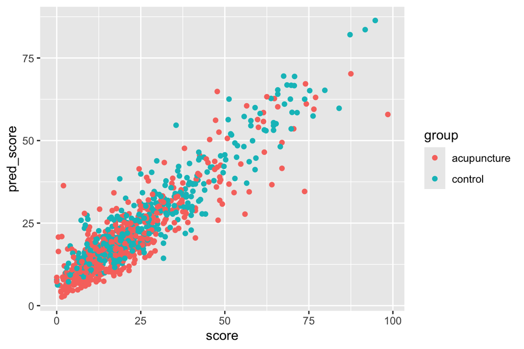

```r
ggplot(data = gp_predictions,
       mapping = aes(x=score, y=pred_score, color = group))+
  geom_point()
```

Yes they do! This looks like a pretty reasonable model.

### Histograms

Look at the distributions of BLUP values

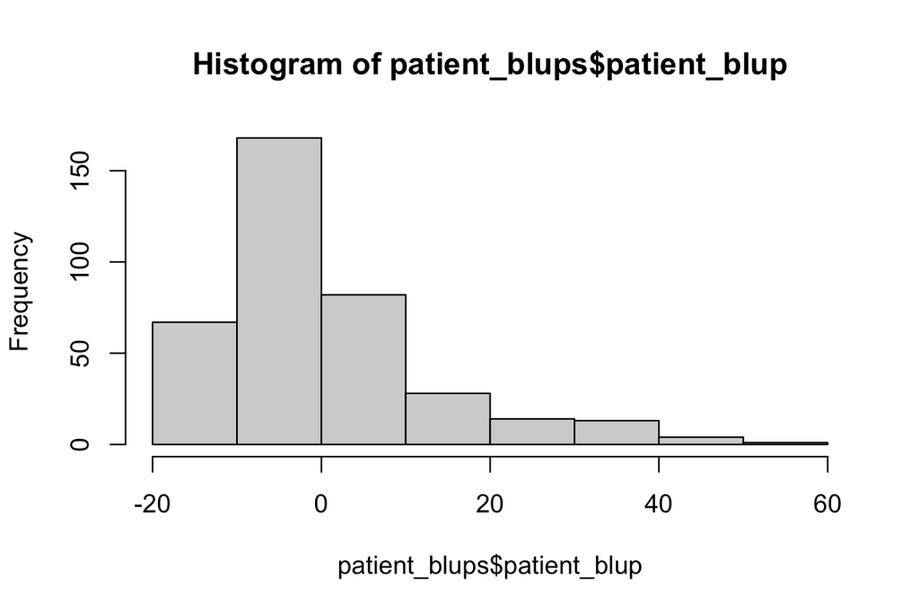

```r
hist(patient_blups$patient_blup)
```

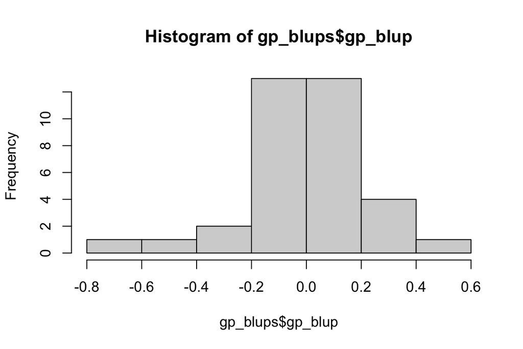

```r
hist(gp_blups$gp_blup)
```

There is much greater variation among the patient BLUPs than the GP BLUPs. This could also be observed with the variances from the model summary. It seems like there is much greater variation among individual people than there is among different GPs. To me this indicates that GP care is highly standardized, and quality of care doesn’t depend much on which GP you go to.

The distribution of BLUPs is supposed to be Normal centered on 0, but that doesn’t seem to be the case with the patient BLUPs. Could this indicate a problem, or poor model fit?

### Spaghetti plots

#### GP effect

Because GP variation is so small compared to person variation, a random sample may result in GPs that are so similar as to be visually indistinguishable. Therefore, for purposes of visualization, I’ll deliberately choose two GPs from opposite ends of the estimated effect spectrum.

```r
# Create a dataframe to check effect estimates for each GP
gp_variation <- gp_predictions %>%
  filter(!is.na(score)) %>% # to get a practical observation count
  group_by(gp, gp_eff) %>%
  summarize(obs = n()) %>%
  arrange(gp_eff)
```

```
`summarise()` has regrouped the output.
ℹ Summaries were computed grouped by gp and gp_eff.
ℹ Output is grouped by gp.
ℹ Use `summarise(.groups = "drop_last")` to silence this message.
ℹ Use `summarise(.by = c(gp, gp_eff))` for per-operation grouping
  (`?dplyr::dplyr_by`) instead.
```

```r
# View GPs with the lowest effect estimates
head(gp_variation)
```

```
# A tibble: 6 × 3
# Groups:   gp [6]
  gp    gp_eff   obs
  <fct>  <dbl> <int>
1 16    -0.701    59
2 11    -0.579    41
3 22    -0.359    35
4 12    -0.262    79
5 35    -0.180     4
6 24    -0.147     5
```

```r
# View GPs with the highest effect estimates
tail(gp_variation)
```

```
# A tibble: 6 × 3
# Groups:   gp [6]
  gp    gp_eff   obs
  <fct>  <dbl> <int>
1 15     0.192    41
2 32     0.235     3
3 41     0.236    78
4 28     0.260    15
5 10     0.272    56
6 17     0.441    33
```

Based on the above, I’ll use GPs 22 and 28 for my visualization. They have a (relatively) large difference in effect estimates, and a workable number of observations.

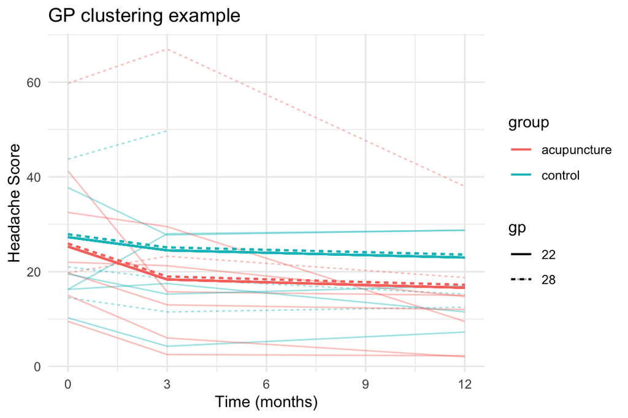

```r
# Identify the GPs I want to visualize
sample_gps <- c(22, 28)

# Create a dataframe for visualization
gp_sample_dat <- gp_predictions %>%
  filter(gp %in% sample_gps) %>%
  mutate(gp_pred = pred_score - id_eff) # predicted score for this GP

# Create the visualization
ggplot(gp_sample_dat, aes(x=time))+
  geom_line(aes(y=score, group=id, color=group, linetype=gp), alpha=0.4)+
  geom_line(aes(y=gp_pred, group=id, color=group, linetype=gp), linewidth=0.7)+
  scale_x_continuous(breaks = seq(0, 12, by=3))+
  theme_minimal()+
  labs(title = "GP clustering example",
       x = "Time (months)", y = "Headache Score")
```

The faint lines illustrate individual patients’ actual scores, while the bold lines illustrate predicted scores for each (GP, group) combination.

Patients in the acupuncture group (red) tend to have lower scores than those in the control group, so the predicted scores for the acupuncture group are lower than those for the control group. Similarly, patients from GP 22 (solid line) tend to have lower scores than those from GP 28, so the predicted scores for GP 22 are lower than those for GP 28. However, the GP difference is much smaller than the treatment group difference, indicating that one’s treatment group has a much greater effect on their predicted headache score than their GP does.

The predicted acupuncture and control group lines are not parallel, because the model contains a group*time interaction, allowing the group difference to vary across time. However, the GP lines are parallel because the model lacks a GP*time interaction, requiring the difference between GPs to be constant across all time points.

##### Is GP even significant?

Every interpretation analysis so far has indicated an extremely small GP effect compared to person and group effects. Do we even need a GP effect in the model? Investigate with a likelihood ratio test.

```r
# Fit a model without GP effect or covariates
lmm_id_intercept_reduced_ml <- lmer(score ~ (group * time_cat) + (1 | id),
                                    data = acupunc_long, REML = FALSE)

# Likelihood ratio test
lrtest(lmm_id_intercept_reduced_ml, lmm_gp_intercept_reduced_ml)
```

```
Likelihood ratio test

Model 1: score ~ (group * time_cat) + (1 | id)
Model 2: score ~ (group * time_cat) + (1 | gp) + (1 | gp:id)
  #Df  LogLik Df  Chisq Pr(>Chisq)
1   8 -3812.5
2   9 -3812.5  1 0.0515     0.8204
```

With a p-value of 0.82, it looks like the model with GP effect is not significantly better than the model without! For now I’ll continue analyzing with GP effect since it’s important to both the trial design and our current analysis, but I’ll come back to this idea in the conclusion.

#### Person effect

Create a spaghetti plot to visualize person effect, as well as how shrinkage estimators work.

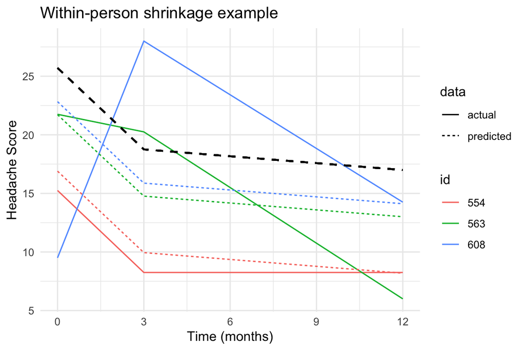

```r
# Create a dataframe of potential patients for visualization
people_sample_dat_ids <- gp_predictions %>%
  # Restrict to only acupuncture patients in the largest GP
  # so that person effect can be isolated:
  filter(group == "acupuncture", gp == "18") %>%
  # Restrict to only patients with complete data
  # for a less confusing visualization:
  group_by(id) %>%
  summarize(score_sum = sum(score, na.rm = FALSE)) %>%
  filter(!is.na(score_sum))

# Get a random sample of 3 patients
set.seed(50)
sample_ids <- sample(people_sample_dat_ids$id, size = 3, replace = FALSE)

# Create a dataframe for visualization
people_sample_dat <- gp_predictions %>%
  filter(id %in% sample_ids) %>%
  mutate(overall_pred = pred_score - id_eff) %>% # predicted score for this group & GP
  pivot_longer(cols = c(score, pred_score),
               names_to = "score_type", values_to = "score_value") %>%
  mutate(data = as.factor(ifelse(score_type=="score", "actual", "predicted")))

# Create the visualization
ggplot(people_sample_dat, aes(x=time)) +
  geom_line(aes(y=score_value, group=interaction(id, data),
                color=id, linetype=data)) +
  geom_line(aes(y=overall_pred, group=interaction(id, data)),
            color="black", linetype="dashed", linewidth=0.7)+
  scale_x_continuous(breaks = seq(0, 12, by=3))+
  theme_minimal() +
  labs(title = "Within-person shrinkage example",
       x = "Time (months)", y = "Headache Score")
```

Colored lines illustrate data for 3 randomly-chosen acupuncture patients from GP 18, while the bold black line illustrates the predicted scores for a generic acupuncture patient from GP 18.

Every patient’s predicted score line is parallel to the generic predicted score line, because the model lacks a patient*time interaction. Furthermore, every patient’s predicted score line is closer to the generic prediction line than their actual data line is, which demonstrates the “shrinkage” property of random effects.

# Mixed model with Acupuncturist effect

Finally, we move on to estimating the acupuncturist effects. To do this, we must restrict to only patients in the acupuncture treatment group. We’ll build on the previously established best GP model.

Outcome variable: `score`

Main predictor variable: `time_cat` (no `group` since it’s now redundant)

Clustering: `acupuncturist`, `gp`, `id`

Covariates: None

```r
# Restrict to acupuncture group
acupunc_long_acu <- acupunc_long %>% filter(group == "acupuncture")
```

Do we need a random slope and intercept for Acupuncturist, or is just a random intercept enough? Investigate with a likelihood ratio test.

## Random intercept for Acupuncturist ID

```r
# Fit the intercept-only model
lmm_acu_intercept <- lmer(score ~ time_cat + (1 | acupuncturist) +
                            (1 | acupuncturist:gp) + (1 | acupuncturist:gp:id),
                          data = acupunc_long_acu)
```

```
boundary (singular) fit: see help('isSingular')
```

```r
summary(lmm_acu_intercept)
```

```
Linear mixed model fit by REML. t-tests use Satterthwaite's method [
lmerModLmerTest]
Formula: score ~ time_cat + (1 | acupuncturist) + (1 | acupuncturist:gp) +
    (1 | acupuncturist:gp:id)
   Data: acupunc_long_acu

REML criterion at convergence: 4009

Scaled residuals:
    Min      1Q  Median      3Q     Max
-3.7022 -0.4599 -0.1307  0.3863  4.7466

Random effects:
 Groups              Name        Variance Std.Dev.
 acupuncturist:gp:id (Intercept) 142.31   11.930
 acupuncturist:gp    (Intercept)   0.00    0.000
 acupuncturist       (Intercept)   0.00    0.000
 Residual                         81.17    9.009
Number of obs: 510, groups:
acupuncturist:gp:id, 194; acupuncturist:gp, 33; acupuncturist, 12

Fixed effects:
            Estimate Std. Error       df t value Pr(>|t|)
(Intercept)  25.6529     1.0733 290.4602  23.901  < 2e-16 ***
time_catpk2  -6.9816     0.9801 322.5544  -7.123 6.91e-12 ***
time_catpk5  -8.8104     1.0074 324.4987  -8.745  < 2e-16 ***
---
Signif. codes:  0 '***' 0.001 '**' 0.01 '*' 0.05 '.' 0.1 ' ' 1

Correlation of Fixed Effects:
            (Intr) tm_ct2
time_catpk2 -0.398
time_catpk5 -0.387  0.469
optimizer (nloptwrap) convergence code: 0 (OK)
boundary (singular) fit: see help('isSingular')
```

## Random slope and intercept for Acupuncturist ID

```r
# Fit the slopes-and-intercepts model
lmm_acu_slope <- lmer(score ~ time_cat + (time_cat | acupuncturist) +
                        (1 | acupuncturist:gp) + (1 | acupuncturist:gp:id),
                      data = acupunc_long_acu)
```

```
boundary (singular) fit: see help('isSingular')
```

```r
summary(lmm_acu_slope)
```

```
Linear mixed model fit by REML. t-tests use Satterthwaite's method [
lmerModLmerTest]
Formula:
score ~ time_cat + (time_cat | acupuncturist) + (1 | acupuncturist:gp) +
    (1 | acupuncturist:gp:id)
   Data: acupunc_long_acu

REML criterion at convergence: 4007.9

Scaled residuals:
    Min      1Q  Median      3Q     Max
-3.6593 -0.4687 -0.1258  0.3916  4.6291

Random effects:
 Groups              Name        Variance  Std.Dev.  Corr
 acupuncturist:gp:id (Intercept) 1.422e+02 1.193e+01
 acupuncturist:gp    (Intercept) 1.114e-08 1.055e-04
 acupuncturist       (Intercept) 0.000e+00 0.000e+00
                     time_catpk2 4.687e+00 2.165e+00  NaN
                     time_catpk5 5.447e-01 7.380e-01  NaN 1.00
 Residual                        8.005e+01 8.947e+00
Number of obs: 510, groups:
acupuncturist:gp:id, 194; acupuncturist:gp, 33; acupuncturist, 12

Fixed effects:
            Estimate Std. Error      df t value Pr(>|t|)
(Intercept)   25.653      1.070 287.662  23.966  < 2e-16 ***
time_catpk2   -7.001      1.232   5.350  -5.683  0.00188 **
time_catpk5   -8.812      1.033  15.275  -8.528 3.39e-07 ***
---
Signif. codes:  0 '***' 0.001 '**' 0.01 '*' 0.05 '.' 0.1 ' ' 1

Correlation of Fixed Effects:
            (Intr) tm_ct2
time_catpk2 -0.313
time_catpk5 -0.373  0.512
optimizer (nloptwrap) convergence code: 0 (OK)
boundary (singular) fit: see help('isSingular')
```

## Choosing the best Acupuncturist model

```r
# Refit the above models using ML
lmm_acu_intercept_ml <- lmer(score ~ time_cat + (1 | acupuncturist) +
                               (1 | acupuncturist:gp) +
                               (1 | acupuncturist:gp:id),
                             data = acupunc_long_acu, REML = FALSE)
```

```
boundary (singular) fit: see help('isSingular')
```

```r
lmm_acu_slope_ml <- lmer(score ~ time_cat + (time_cat | acupuncturist) +
                           (1 | acupuncturist:gp) + (1 | acupuncturist:gp:id),
                         data = acupunc_long_acu,  REML = FALSE)
```

```
boundary (singular) fit: see help('isSingular')
```

```r
# Likelihood ratio test
lrtest(lmm_acu_intercept_ml, lmm_acu_slope_ml)
```

```
Likelihood ratio test

Model 1: score ~ time_cat + (1 | acupuncturist) + (1 | acupuncturist:gp) +
    (1 | acupuncturist:gp:id)
Model 2: score ~ time_cat + (time_cat | acupuncturist) + (1 | acupuncturist:gp) +
    (1 | acupuncturist:gp:id)
  #Df  LogLik Df  Chisq Pr(>Chisq)
1   7 -2007.1
2  12 -2006.6  5 0.9084     0.9696
```

With a p-value of 0.96, the random slopes model is not significantly better.

However, before we decide on our best model, recall that the Acupuncturist intercepts-only model had 0 variance on some random effects. According to `help('isSingular')`, this indicates that the model is too complex for the data to support. Therefore, it may be best to remove the effects with 0 variance; in this case, `acupuncturist` and `acupuncturist:gp`. That said, I don’t want to remove the effects that are essential to the trial design. To explore this further, I’ll use a likelihood ratio test to determine if a model without Acupuncturist and GP random effects is really no worse.

```r
lmm_acu_simplified_ml <- lmer(score ~ time_cat + (1 | acupuncturist:gp:id),
                              data = acupunc_long_acu,  REML = FALSE)

lrtest(lmm_acu_simplified_ml, lmm_acu_intercept_ml)
```

```
Likelihood ratio test

Model 1: score ~ time_cat + (1 | acupuncturist:gp:id)
Model 2: score ~ time_cat + (1 | acupuncturist) + (1 | acupuncturist:gp) +
    (1 | acupuncturist:gp:id)
  #Df  LogLik Df Chisq Pr(>Chisq)
1   5 -2007.1
2   7 -2007.1  2     0          1
```

With a p-value of 1, the model with GP and Acupuncturist effect is not significantly better than the one without. Interesting! This suggests that all GPs and Acupuncturists are extremely similar to one another, which may support that acupuncture is a standardized science and the treatment effect is unlikely to be a placebo.

Nevertheless, the Acupuncturist and GP effects are important to both the original trial and my current analysis, so I will proceed with the full intercepts-only model.

## Interpretation

To recap, the best Acupuncturist model is:

```r
summary(lmm_acu_intercept)
```

```
Linear mixed model fit by REML. t-tests use Satterthwaite's method [
lmerModLmerTest]
Formula: score ~ time_cat + (1 | acupuncturist) + (1 | acupuncturist:gp) +
    (1 | acupuncturist:gp:id)
   Data: acupunc_long_acu

REML criterion at convergence: 4009

Scaled residuals:
    Min      1Q  Median      3Q     Max
-3.7022 -0.4599 -0.1307  0.3863  4.7466

Random effects:
 Groups              Name        Variance Std.Dev.
 acupuncturist:gp:id (Intercept) 142.31   11.930
 acupuncturist:gp    (Intercept)   0.00    0.000
 acupuncturist       (Intercept)   0.00    0.000
 Residual                         81.17    9.009
Number of obs: 510, groups:
acupuncturist:gp:id, 194; acupuncturist:gp, 33; acupuncturist, 12

Fixed effects:
            Estimate Std. Error       df t value Pr(>|t|)
(Intercept)  25.6529     1.0733 290.4602  23.901  < 2e-16 ***
time_catpk2  -6.9816     0.9801 322.5544  -7.123 6.91e-12 ***
time_catpk5  -8.8104     1.0074 324.4987  -8.745  < 2e-16 ***
---
Signif. codes:  0 '***' 0.001 '**' 0.01 '*' 0.05 '.' 0.1 ' ' 1

Correlation of Fixed Effects:
            (Intr) tm_ct2
time_catpk2 -0.398
time_catpk5 -0.387  0.469
optimizer (nloptwrap) convergence code: 0 (OK)
boundary (singular) fit: see help('isSingular')
```

The fixed effects estimates from this model are extremely similar to the ones from our best GP model! This indicates that restricting the acupuncture patients only and adding an acupuncturist effect doesn’t change the predicted time effects much. (Previous fixed effect estimates: 25.6640 for `Intercept`, -6.9533 for `time_catpk2`, -8.7103 for `time_catpk5`.)

However there is a major problem with this Acupuncturist model: because the variances on `acupuncturist` and `acupuncturist:gp` are 0, we actually cannot obtain (meaningful) BLUPs! Therefore it is impossible to create histograms or spaghetti plots as I did before.

To address this problem, let’s try removing the GP effect, since we found that the GP effect didn’t improve the model anyway. Does removing GP free up enough degrees of freedom to estimate an acupuncturist effect?

```r
# Fit a model without GP effect
lmm_acu_intercept_noGP <- lmer(score ~ time_cat + (1 | acupuncturist) +
                                 (1 | acupuncturist:id),
                          data = acupunc_long_acu)
```

```
boundary (singular) fit: see help('isSingular')
```

```r
summary(lmm_acu_intercept_noGP)
```

```
Linear mixed model fit by REML. t-tests use Satterthwaite's method [
lmerModLmerTest]
Formula: score ~ time_cat + (1 | acupuncturist) + (1 | acupuncturist:id)
   Data: acupunc_long_acu

REML criterion at convergence: 4009

Scaled residuals:
    Min      1Q  Median      3Q     Max
-3.7022 -0.4599 -0.1307  0.3863  4.7466

Random effects:
 Groups           Name        Variance Std.Dev.
 acupuncturist:id (Intercept) 142.31   11.930
 acupuncturist    (Intercept)   0.00    0.000
 Residual                      81.17    9.009
Number of obs: 510, groups:  acupuncturist:id, 194; acupuncturist, 12

Fixed effects:
            Estimate Std. Error       df t value Pr(>|t|)
(Intercept)  25.6529     1.0733 290.4599  23.901  < 2e-16 ***
time_catpk2  -6.9816     0.9801 322.5545  -7.123 6.91e-12 ***
time_catpk5  -8.8104     1.0074 324.4988  -8.745  < 2e-16 ***
---
Signif. codes:  0 '***' 0.001 '**' 0.01 '*' 0.05 '.' 0.1 ' ' 1

Correlation of Fixed Effects:
            (Intr) tm_ct2
time_catpk2 -0.398
time_catpk5 -0.387  0.469
optimizer (nloptwrap) convergence code: 0 (OK)
boundary (singular) fit: see help('isSingular')
```

Nope, we’re still getting `boundary (singular)` and 0 variance on the `acupuncturist` random effect.

As a last-ditch effort, what if we remove the individual patient effects?

```r
# Fit a model with only acupuncturist effect
lmm_acu_intercept_reduced <- lmer(score ~ time_cat + (1 | acupuncturist),
                          data = acupunc_long_acu)
summary(lmm_acu_intercept_reduced)
```

```
Linear mixed model fit by REML. t-tests use Satterthwaite's method [
lmerModLmerTest]
Formula: score ~ time_cat + (1 | acupuncturist)
   Data: acupunc_long_acu

REML criterion at convergence: 4177.8

Scaled residuals:
    Min      1Q  Median      3Q     Max
-1.2281 -0.6732 -0.2806  0.3841  5.4343

Random effects:
 Groups        Name        Variance Std.Dev.
 acupuncturist (Intercept)   0.4702  0.6857
 Residual                  214.9111 14.6598
Number of obs: 510, groups:  acupuncturist, 12

Fixed effects:
            Estimate Std. Error      df t value Pr(>|t|)
(Intercept)   25.698      1.080  55.011  23.787  < 2e-16 ***
time_catpk2   -7.137      1.555 502.806  -4.589 5.63e-06 ***
time_catpk5   -9.805      1.588 502.741  -6.174 1.37e-09 ***
---
Signif. codes:  0 '***' 0.001 '**' 0.01 '*' 0.05 '.' 0.1 ' ' 1

Correlation of Fixed Effects:
            (Intr) tm_ct2
time_catpk2 -0.659
time_catpk5 -0.645  0.449
```

Since it’s difficult to estimate the acupuncturist effect, and removing it from the model doesn’t result in worse performance, I conclude that there is no meaningful variation among individual acupuncturists, supporting the conclusion that that acupuncture is a standardized science and that the treatment effect is unlikely to be a placebo.

# Conclusion

In conclusion, our mixed model analysis found a highly significant treatment effect, consistent with the original findings from Vickers et al.

Our repeated measures design allowed us to observe how headache scores change over time in both groups. We found that acupuncture appears to have the greatest effect shortly after treatment (before 3 months), but that even after 3 months, headache scores continue to gradually decrease.

We also investigated the effects of individual person, GP, and acupuncturist. We found little variation among GP and acupuncturist compared to individual patient, suggesting that both GPs and acupuncturists are highly standardized in terms of the quality of care they provide. This may support the idea that the theraputic effect of acupuncture is due to a physiological mechanism and not a placebo.